# How do we want to display TEMPORAL data?

Jessica Couture

5/22/2016

## Emphasize percents? number of datasets? differences between years?…

We have talked about a number of different ways to display these results. Here I show 2 of the variables discussed:

- Look at all years projects were funded or just the last year?
- Use percent successful or number of datasets?

Below I have plotted first the data looking at only the last year of funding (so these would represent the amount of time since a project was finished) as raw number of datasets and percents, then look at the data collected for each year a dataset was funded. I can think of pros and cons for each so this needs to be discussed

I didn’t start with stats because I haven’t run any, something else we need to discuss….

> Q4. Is the availability of data correlated to how old the data are? (temporal relationships?)

#### **Plots of data reporting based on the year project funding *ended,* to represent length of time since data were created:**

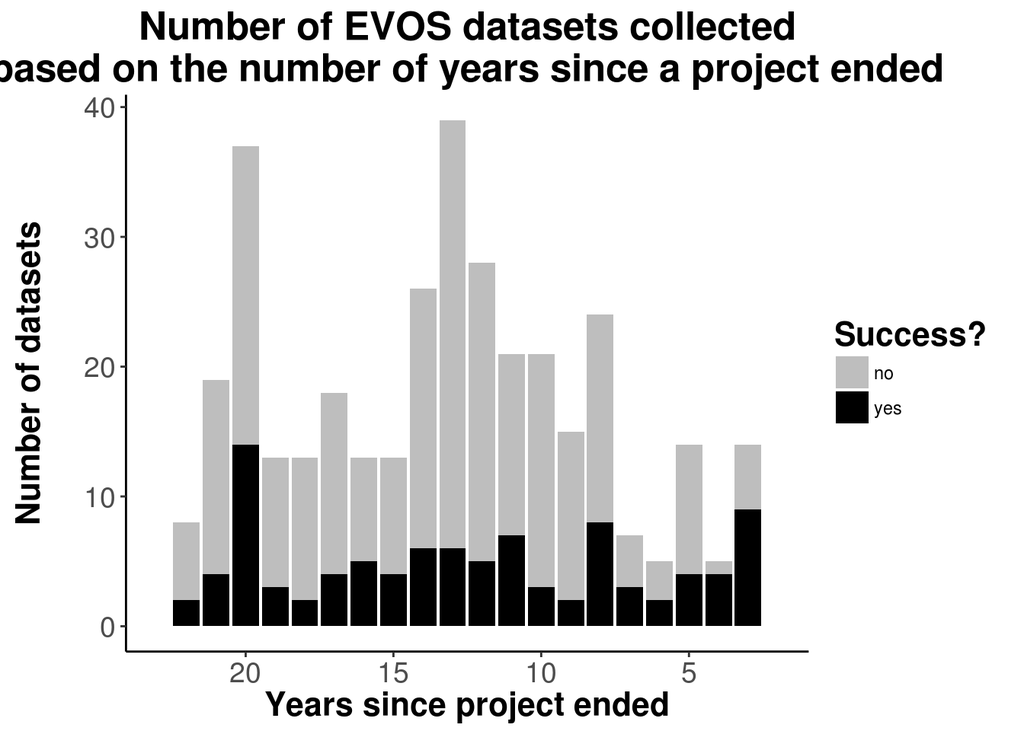

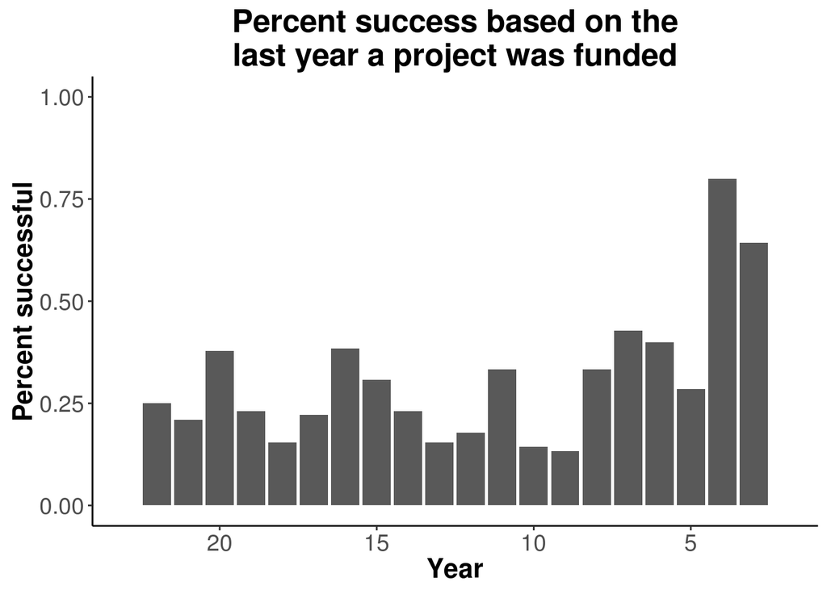

#### **These plots show results based on each year a project received funding**

Ex: a project funded from 1994-1997 would be counted 4 times: 1994, 1995, 1996, 1997

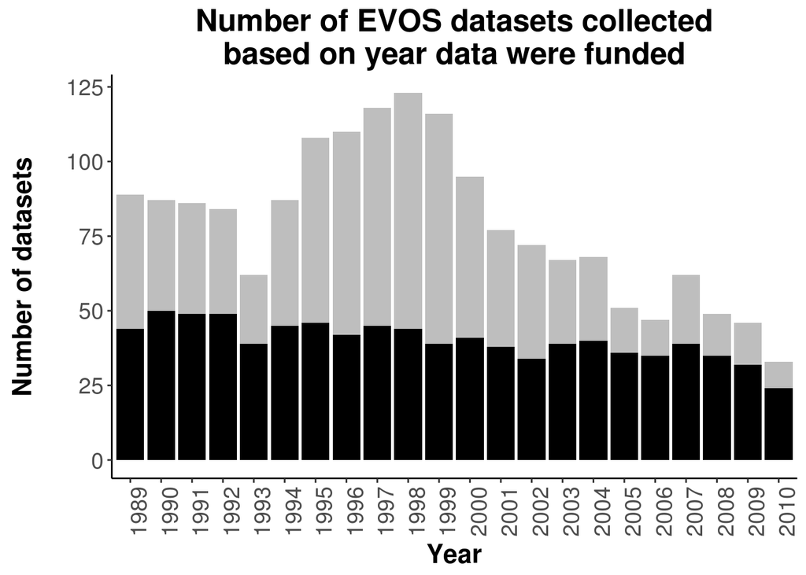

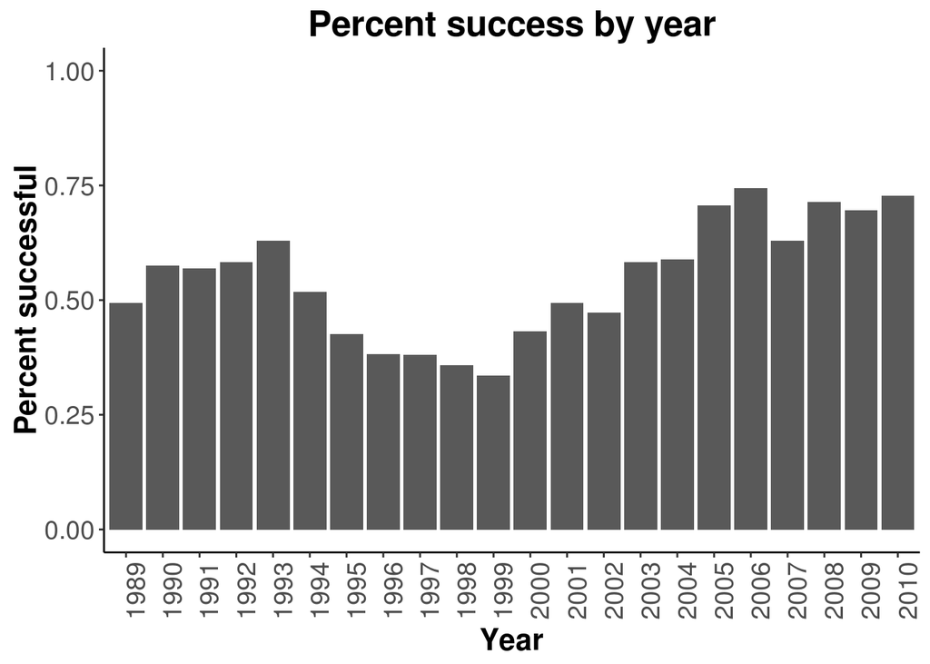

#### **Combining the plots together:**

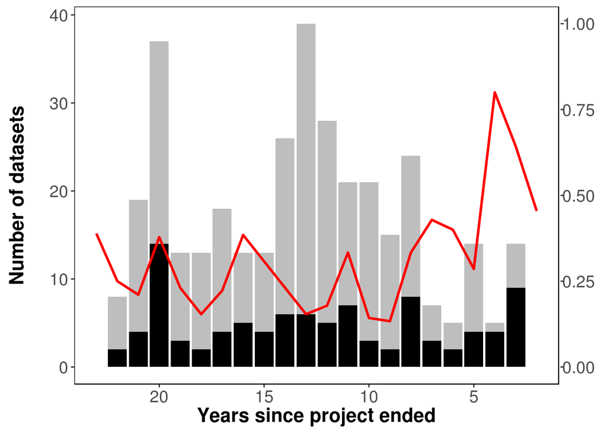

#### **Two plots:**

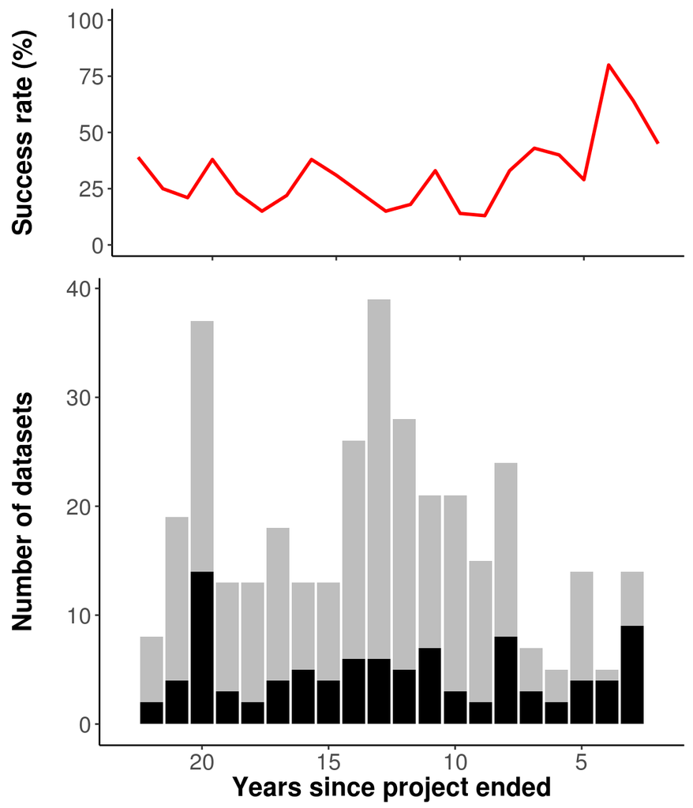

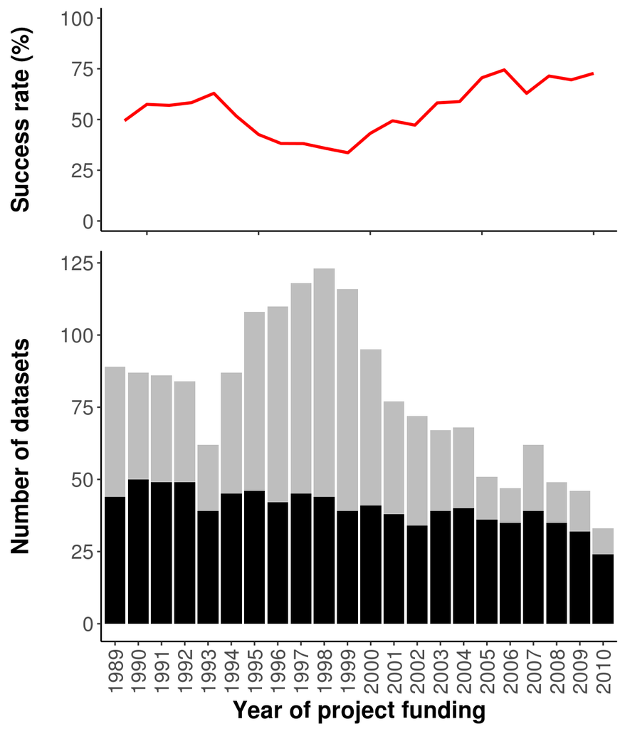